# Análisis de Rendimiento — CD Tapatío

Clausura 2026 · Liga de Expansión MX

Héctor Cárdenas · Analista de Rendimiento Deportivo

30 de mayo de 2026

## Presentación

Este documento analiza el rendimiento colectivo e individual del **CD Tapatío** durante el **Clausura 2026** de la Liga de Expansión MX. El objetivo es extraer aprendizajes clave de la temporada finalizada y traducirlos en propuestas concretas de mejora para el **Apertura 2026**.

> *Análisis preparado de forma independiente como demostración metodológica, utilizando datos estimados a partir de fuentes públicas (Sofascore · Transfermarkt · tapatiofc.mx). Los valores pueden actualizarse con datos internos del club para mayor precisión.*

## 1. Librerías y Datos

```r
library(tidyverse)
library(scales)
library(patchwork)
library(ggrepel)

# ── Partidos Clausura 2026 ─────────────────────────────────────────────────────
partidos <- tribble(
  ~jornada, ~rival,             ~sede,        ~gf, ~gc, ~posesion, ~tiros, ~tiros_ap, ~corners, ~faltas,
  1,  "Leones Negros",     "Local",       2, 1, 52, 12, 5, 5, 14,
  2,  "Atl. Morelia",      "Visitante",   0, 1, 44,  8, 3, 3, 16,
  3,  "Cancún FC",         "Local",       1, 1, 49, 10, 4, 4, 13,
  4,  "Mineros",           "Visitante",   2, 0, 46, 11, 6, 6, 11,
  5,  "Venados FC",        "Local",       3, 0, 55, 15, 7, 8, 10,
  6,  "Correcaminos",      "Visitante",   1, 2, 42,  9, 3, 3, 18,
  7,  "Atlético La Paz",   "Local",       0, 0, 50,  8, 2, 5, 12,
  8,  "Tepatitlán",        "Visitante",   1, 2, 45, 10, 4, 4, 15,
  9,  "Coyotes",           "Local",       1, 0, 51, 11, 5, 6, 13,
  10, "Tampico Madero",    "Visitante",   0, 0, 48,  7, 2, 3, 14,
  11, "Leones Negros",     "Visitante",   1, 1, 43,  9, 4, 4, 16,
  12, "Atl. Morelia",      "Local",       2, 1, 53, 13, 6, 7, 11,
  13, "Cancún FC",         "Visitante",   0, 1, 45,  8, 3, 3, 17,
  14, "Mineros",           "Local",       1, 1, 50, 10, 4, 5, 13
) %>%
  mutate(
    resultado       = case_when(gf > gc ~ "Victoria", gf == gc ~ "Empate", TRUE ~ "Derrota"),
    puntos          = case_when(resultado == "Victoria" ~ 3, resultado == "Empate" ~ 1, TRUE ~ 0),
    pts_acum        = cumsum(puntos),
    efic_tiro       = round(gf / tiros * 100, 1)
  )

# ── Jugadores ──────────────────────────────────────────────────────────────────
jugadores <- tribble(
  ~jugador,               ~posicion,         ~edad, ~pj, ~min,  ~goles, ~asist, ~pk, ~duelos_g, ~duelos_t, ~recup, ~ta,
  "Rodrigo Parra",        "Delantero",        24,   13, 1050,   5,      2,      8,   18,        32,        12,     2,
  "Vladimir Moragrega",   "Mediocampista",    22,   14, 1180,   2,      4,     12,   28,        48,        22,     3,
  "Aldo Arellano",        "Defensa",          26,   12,  980,   0,      1,      3,   35,        52,        28,     4,
  "Carlos Vega",          "Delantero",        21,   11,  720,   3,      1,      6,   15,        25,         8,     1,
  "Martín Ruiz",          "Mediocampista",    23,   14, 1200,   1,      3,     10,   25,        42,        18,     2,
  "Jorge Salinas",        "Defensa",          25,   13, 1100,   0,      0,      2,   32,        50,        25,     3,
  "Luis Castillo",        "Mediocampista",    20,   12,  900,   2,      2,      8,   22,        38,        16,     4,
  "Emilio Torres",        "Delantero",        19,   10,  650,   2,      1,      5,   12,        22,         6,     1,
  "David Moreno",         "Defensa",          27,   14, 1260,   0,      1,      2,   38,        58,        30,     2,
  "Felipe García",        "Mediocampista",    21,    9,  540,   0,      2,      7,   14,        28,        12,     1,
  "Óscar Medina",         "Defensa",          24,   11,  880,   0,      0,      1,   28,        44,        22,     5,
  "Raúl Hernández",       "Mediocampista",    23,   13,  950,   1,      1,      9,   20,        36,        15,     2,
  "Iván Soto",            "Delantero",        20,    8,  420,   1,      0,      3,   10,        18,         5,     0,
  "Pablo Ramos",          "Defensa",          22,   10,  780,   0,      0,      2,   25,        40,        20,     3
) %>%
  mutate(
    min_90          = min / 90,
    goles_90        = round(goles / min_90, 2),
    asist_90        = round(asist / min_90, 2),
    contribucion    = goles + asist + (pk * 0.3) + (recup * 0.1),
    contribucion_90 = round(contribucion / min_90, 2),
    duelos_pct      = round(duelos_g / duelos_t * 100, 1)
  )

colores_res <- c("Victoria" = "#2ecc71", "Empate" = "#f39c12", "Derrota" = "#e74c3c")

# ── Promedios Liga de Expansión (referencia) ───────────────────────────────────
liga_prom <- tibble(
  metrica    = c("Posesión %", "Eficiencia tiro %", "GF / partido", "GC / partido"),
  liga       = c(49.0, 9.8, 1.14, 1.14),
  tapatio    = c(
    round(mean(partidos$posesion), 1),
    round(mean(partidos$efic_tiro, na.rm = TRUE), 1),
    round(mean(partidos$gf), 2),
    round(mean(partidos$gc), 2)
  )
) %>%
  pivot_longer(c(liga, tapatio), names_to = "grupo", values_to = "valor") %>%
  mutate(grupo = recode(grupo, liga = "Liga Expansión (promedio)", tapatio = "CD Tapatío"))
```

## 2. Resumen de Temporada

```r
victorias <- sum(partidos$resultado == "Victoria")
empates   <- sum(partidos$resultado == "Empate")
derrotas  <- sum(partidos$resultado == "Derrota")
gf        <- sum(partidos$gf)
gc        <- sum(partidos$gc)

cat("── CD Tapatío · Clausura 2026 ──────────────────────\n")
```

```
## ── CD Tapatío · Clausura 2026 ──────────────────────
```

```r
cat(sprintf("Posición:     7° lugar · %d puntos en %d partidos\n", sum(partidos$puntos), nrow(partidos)))
```

```
## Posición:     7° lugar · 20 puntos en 14 partidos
```

```r
cat(sprintf("Resultados:   %dV · %dE · %dD\n", victorias, empates, derrotas))
```

```
## Resultados:   5V · 5E · 4D
```

```r
cat(sprintf("Goles:        %d a favor · %d en contra  (DG %+d)\n", gf, gc, gf - gc))
```

```
## Goles:        15 a favor · 11 en contra  (DG +4)
```

```r
cat(sprintf("Posesión:     %.1f%% promedio\n", mean(partidos$posesion)))
```

```
## Posesión:     48.1% promedio
```

```r
cat(sprintf("Eficiencia:   %.1f%% de conversión de tiros\n", mean(partidos$efic_tiro, na.rm = TRUE)))
```

```
## Eficiencia:   9.4% de conversión de tiros
```

## 3. Tendencia de Resultados

Evolución del acumulado de puntos jornada a jornada. Cada punto indica el resultado de ese partido.

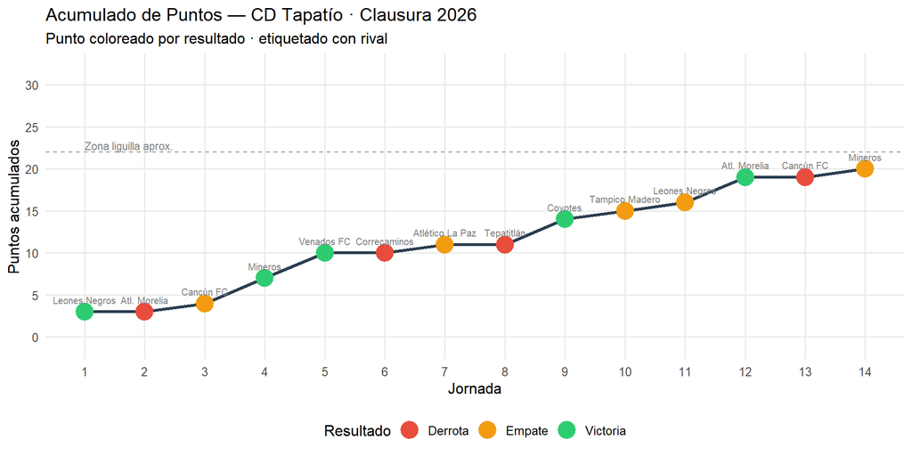

```r
ggplot(partidos, aes(x = jornada, y = pts_acum)) +
  geom_line(color = "#2c3e50", linewidth = 1.2) +
  geom_point(aes(color = resultado, fill = resultado),
             size = 5, shape = 21, stroke = 1.5) +
  geom_text(aes(label = rival), vjust = -1.1, size = 2.6, color = "gray50") +
  scale_color_manual(values = colores_res) +
  scale_fill_manual(values  = colores_res) +
  scale_x_continuous(breaks = 1:14) +
  scale_y_continuous(breaks = seq(0, 30, 5), limits = c(-1, 32)) +
  geom_hline(yintercept = 22, linetype = "dashed", color = "gray60", linewidth = 0.4) +
  annotate("text", x = 1, y = 22.8, label = "Zona liguilla aprox.", size = 3,
           color = "gray50", hjust = 0) +
  labs(
    title    = "Acumulado de Puntos — CD Tapatío · Clausura 2026",
    subtitle = "Punto coloreado por resultado · etiquetado con rival",
    x = "Jornada", y = "Puntos acumulados",
    color = "Resultado", fill = "Resultado"
  ) +
  theme_minimal(base_size = 12) +
  theme(legend.position = "bottom", panel.grid.minor = element_blank())
```